# Traffic Accident Analysis in Addis Ababa

2024-11-07

# Background and Problem definitions

Traffic accidents are among the leading causes of injury and death globally. Most importantly, the study of causes and antecedents of these mishaps will go a long way in enhancing road safety, and hence decreasing the fatality rate. In this research, the Road Traffic Accident Dataset of Addis Ababa City is employed to analyze the correlation between antecedent conditions such as weather conditions, driver’s experience, and the Road Alignment and Traffic congestion, with the extent of accident severity.

Specific inputs from the data set include details of over 12000 accidents that occurred between 2017 and 2020, and the circumstances when they occurred including time, location, type of vehicle and conditions at the time of the accident. Particularly, this work will be aimed at identifying specific characteristics of severe accident types because they have the highest impact on public health.

The issue under focus in this study is the analysis of severe road traffic accidents to determine their main antecedents. Thus, working with this dataset, the aim is to identify potential patterns as to how different variables such as weather condition, drivers’ experience, road gradients and much more are linked to the severity of the accidents. The findings generated from the analysis may serve to enhance the creation of safer prevention strategies that may assist policymakers, traffic authorities, and the public to minimize the number of fatal accidents on the road.

## Objective

This project seeks to answer the following research questions: 1. What are the most common causes of road traffic accidents in Addis Ababa, and how frequently do they occur?

2. How the Accidents are distributed among the male and female Drivers?
3. How the Accidents are distributed among the Age Band of Drivers?
4. What is the realtion between the experince of driver and the number of accidents?
5. What is the distribution of road accidents by the type of vehicle involved?
6. Is there a correlation between road surface conditions and accident severity?
7. Are there any noticeable trends in accident severity by road alignment type (e.g., curved, flat terrain)?
8. What factors most predict severe accidents (e.g., weather, driving experience, road alignment)?

# Data Wrangling and Cleaning

```r
# Load necessary libraries
library(tidyverse)
```

```r
library(lubridate)
library(ggplot2)
library(dplyr)
```

```r
# Load the dataset
accidents <- read.csv("RTA Dataset.csv")

# Inspect the dataset
str(accidents)
```

```
## 'data.frame':    12316 obs. of  32 variables:
##  $ Time                       : chr  "17:02:00" "17:02:00" "17:02:00" "1:06:00" ...
##  $ Day_of_week                : chr  "Monday" "Monday" "Monday" "Sunday" ...
##  $ Age_band_of_driver         : chr  "18-30" "31-50" "18-30" "18-30" ...
##  $ Sex_of_driver              : chr  "Male" "Male" "Male" "Male" ...
##  $ Educational_level          : chr  "Above high school" "Junior high school" "Junior high school" "Junior high school" ...
##  $ Vehicle_driver_relation    : chr  "Employee" "Employee" "Employee" "Employee" ...
##  $ Driving_experience         : chr  "1-2yr" "Above 10yr" "1-2yr" "5-10yr" ...
##  $ Type_of_vehicle            : chr  "Automobile" "Public (> 45 seats)" "Lorry (41?100Q)" "Public (> 45 seats)" ...
##  $ Owner_of_vehicle           : chr  "Owner" "Owner" "Owner" "Governmental" ...
##  $ Service_year_of_vehicle    : chr  "Above 10yr" "5-10yrs" "" "" ...
##  $ Defect_of_vehicle          : chr  "No defect" "No defect" "No defect" "No defect" ...
##  $ Area_accident_occured      : chr  "Residential areas" "Office areas" "  Recreational areas" "Office areas" ...
##  $ Lanes_or_Medians           : chr  "" "Undivided Two way" "other" "other" ...
##  $ Road_allignment            : chr  "Tangent road with flat terrain" "Tangent road with flat terrain" "" "Tangent road with mild grade and flat terrain" ...
```

[output cut: 18 more lines]

```r
summary(accidents)
```

```
##      Time           Day_of_week        Age_band_of_driver Sex_of_driver
##  Length:12316       Length:12316       Length:12316       Length:12316
##  Class :character   Class :character   Class :character   Class :character
##  Mode  :character   Mode  :character   Mode  :character   Mode  :character
##
##
##
##  Educational_level  Vehicle_driver_relation Driving_experience
##  Length:12316       Length:12316            Length:12316
##  Class :character   Class :character        Class :character
##  Mode  :character   Mode  :character        Mode  :character
##
##
##
##  Type_of_vehicle    Owner_of_vehicle   Service_year_of_vehicle
##  Length:12316       Length:12316       Length:12316
##  Class :character   Class :character   Class :character
##  Mode  :character   Mode  :character   Mode  :character
##
##
##
##  Defect_of_vehicle  Area_accident_occured Lanes_or_Medians   Road_allignment
##  Length:12316       Length:12316          Length:12316       Length:12316
##  Class :character   Class :character      Class :character   Class :character
##  Mode  :character   Mode  :character      Mode  :character   Mode  :character
##
##
##
##  Types_of_Junction  Road_surface_type  Road_surface_conditions
##  Length:12316       Length:12316       Length:12316
##  Class :character   Class :character   Class :character
##  Mode  :character   Mode  :character   Mode  :character
##
##
##
##  Light_conditions   Weather_conditions Type_of_collision
##  Length:12316       Length:12316       Length:12316
##  Class :character   Class :character   Class :character
##  Mode  :character   Mode  :character   Mode  :character
##
```

[output cut: 15 more lines]

```
##
##  Work_of_casuality  Fitness_of_casuality Pedestrian_movement Cause_of_accident
##  Length:12316       Length:12316         Length:12316        Length:12316
##  Class :character   Class :character     Class :character    Class :character
##  Mode  :character   Mode  :character     Mode  :character    Mode  :character
##
##
##
##  Accident_severity
##  Length:12316
##  Class :character
##  Mode  :character
##
##
##
```

The columns are being dropped because they either provide irrelevant information for analyzing the main factors of road traffic accidents or contain data that is not central to understanding accident causes, severity, or patterns. This simplification helps focus on the most impactful variables for the analysis.

```r
# Drop the specified columns
cols_to_drop <- c("Time", "Educational_level", "Owner_of_vehicle", "Lanes_or_Medians",
                  "Types_of_Junction", "Casualty_class", "Sex_of_casualty",
                  "Age_band_of_casualty", "Casualty_severity", "Work_of_casuality",
                  "Fitness_of_casuality", "Pedestrian_movement")

# Remove the columns from the dataset
new_accidents <- accidents[, !(names(accidents) %in% cols_to_drop)]

# Check the remaining columns
remaining_columns <- colnames(new_accidents)
print("Remaining Columns After Dropping:")
```

```
## [1] "Remaining Columns After Dropping:"
```

```r
print(remaining_columns)
```

```
##  [1] "Day_of_week"                 "Age_band_of_driver"
##  [3] "Sex_of_driver"               "Vehicle_driver_relation"
##  [5] "Driving_experience"          "Type_of_vehicle"
##  [7] "Service_year_of_vehicle"     "Defect_of_vehicle"
##  [9] "Area_accident_occured"       "Road_allignment"
## [11] "Road_surface_type"           "Road_surface_conditions"
## [13] "Light_conditions"            "Weather_conditions"
## [15] "Type_of_collision"           "Number_of_vehicles_involved"
## [17] "Number_of_casualties"        "Vehicle_movement"
## [19] "Cause_of_accident"           "Accident_severity"
```

## Handling missing values

```r
# Drop rows with missing values
accidents_clean <- na.omit(new_accidents)

# Print the first few rows to check
head(accidents_clean)
```

```
##   Day_of_week Age_band_of_driver Sex_of_driver Vehicle_driver_relation
## 1      Monday              18-30          Male                Employee
## 2      Monday              31-50          Male                Employee
## 3      Monday              18-30          Male                Employee
## 4      Sunday              18-30          Male                Employee
## 5      Sunday              18-30          Male                Employee
## 6      Friday              31-50          Male                 Unknown
##   Driving_experience     Type_of_vehicle Service_year_of_vehicle
## 1              1-2yr          Automobile              Above 10yr
## 2         Above 10yr Public (> 45 seats)                 5-10yrs
## 3              1-2yr     Lorry (41?100Q)
## 4             5-10yr Public (> 45 seats)
## 5              2-5yr                                     5-10yrs
## 6
##   Defect_of_vehicle Area_accident_occured
```

[output cut: 41 more lines]

## 1.What are the most common causes of road traffic accidents in Addis Ababa, and how frequently do they occur?

```r
# Count the total number of accidents for each cause
cause_accidents_count <- table(accidents_clean$Cause_of_accident)

# Convert the table into a data frame for easier manipulation
cause_accidents_df <- as.data.frame(cause_accidents_count)
colnames(cause_accidents_df) <- c("Cause_of_accident", "Total_Accidents")

# Display the result
print(cause_accidents_df)
```

```
##                       Cause_of_accident Total_Accidents
## 1             Changing lane to the left            1473
## 2            Changing lane to the right            1808
## 3                 Driving at high speed             174
## 4                    Driving carelessly            1402
## 5                   Driving to the left             284
## 6  Driving under the influence of drugs             340
## 7                         Drunk driving              27
## 8    Getting off the vehicle improperly             197
## 9                      Improper parking              25
## 10                      Moving Backward            1137
## 11                        No distancing            2263
## 12            No priority to pedestrian             721
## 13               No priority to vehicle            1207
## 14                                Other             456
## 15                          Overloading              59
## 16                            Overspeed              61
## 17                           Overtaking             430
## 18                          Overturning             149
## 19                             Turnover              78
## 20                              Unknown              25
```

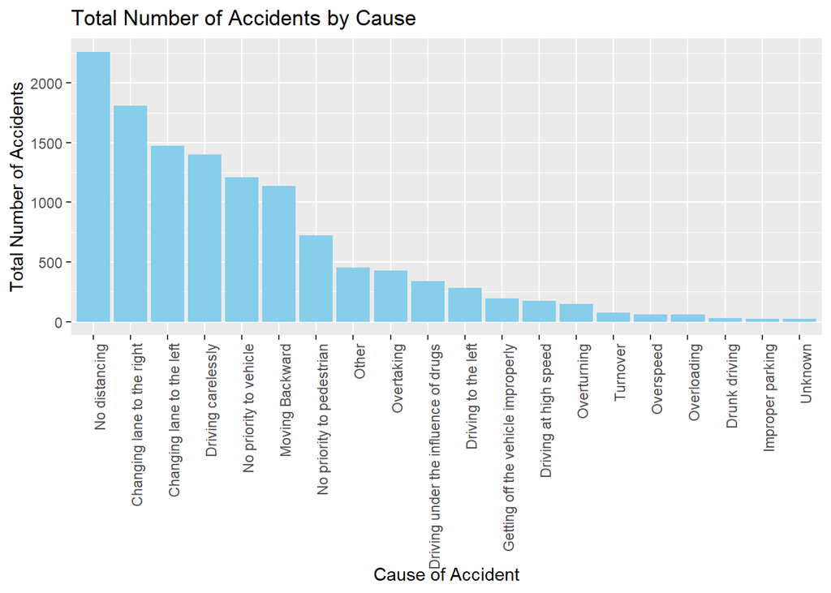

```r
# Visualize the count of accidents by cause
library(ggplot2)
ggplot(cause_accidents_df, aes(x = reorder(Cause_of_accident, -Total_Accidents), y = Total_Accidents)) +
  geom_bar(stat = "identity", fill = "skyblue") +
  labs(title = "Total Number of Accidents by Cause",
       x = "Cause of Accident",
       y = "Total Number of Accidents") +
  theme(axis.text.x = element_text(angle = 90, hjust = 1)) # Rotate x labels for better readability
```

## Answer

The most frequent causes of accidents in Addis Ababa are linked to behaviors like changing lanes improperly, not maintaining adequate distance, and careless driving. Among these, No Distancing is the most prevalent, occurring in over 2,200 incidents. Other common causes include lane changes, careless driving, and lack of priority to vehicles and pedestrians.

## 2. How the Accidents are distributed among the male and female Drivers?

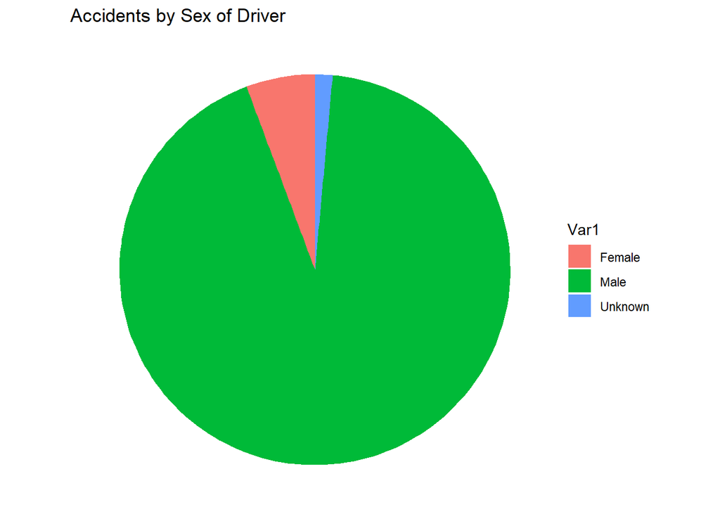

```r
sex_counts <- table(accidents_clean$Sex_of_driver)
ggplot(as.data.frame(sex_counts), aes(x = "", y = Freq, fill = Var1)) +
  geom_bar(stat = "identity", width = 1) +
  coord_polar("y") +
  labs(title = "Accidents by Sex of Driver") +
  theme_void()
```

```r
print(sex_counts)
```

```
##
##  Female    Male Unknown
##     701   11437     178
```

## Answer

The majority of road traffic accidents in Addis Ababa involve male drivers, accounting for a significantly higher number of accidents compared to female drivers. The unknown category also represents a small portion of the total accidents

## 3.How the Accidents are distributed among the Age Band of Drivers?

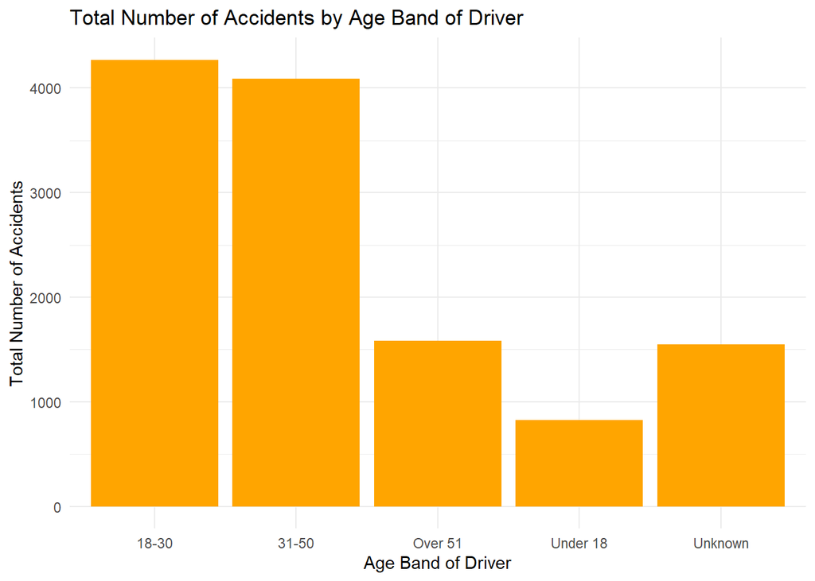

```r
ggplot(accidents_clean, aes(x = Age_band_of_driver)) +
  geom_bar(fill = "orange") +
  labs(title = "Total Number of Accidents by Age Band of Driver", x = "Age Band of Driver", y = "Total Number of Accidents") +
  theme_minimal()
```

```r
# Print total accidents by age band
table(accidents_clean$Age_band_of_driver)
```

```
##
##    18-30    31-50  Over 51 Under 18  Unknown
##     4271     4087     1585      825     1548
```

## Answer

The data shows a higher number of accidents among younger drivers (18-30 years) and those in the 31-50 years group. This suggests that driving experience (or lack of it) is a significant factor in accident occurrence, with younger drivers facing higher risks

## 4. What is the realtion between the experince of driver and the number of accidents?

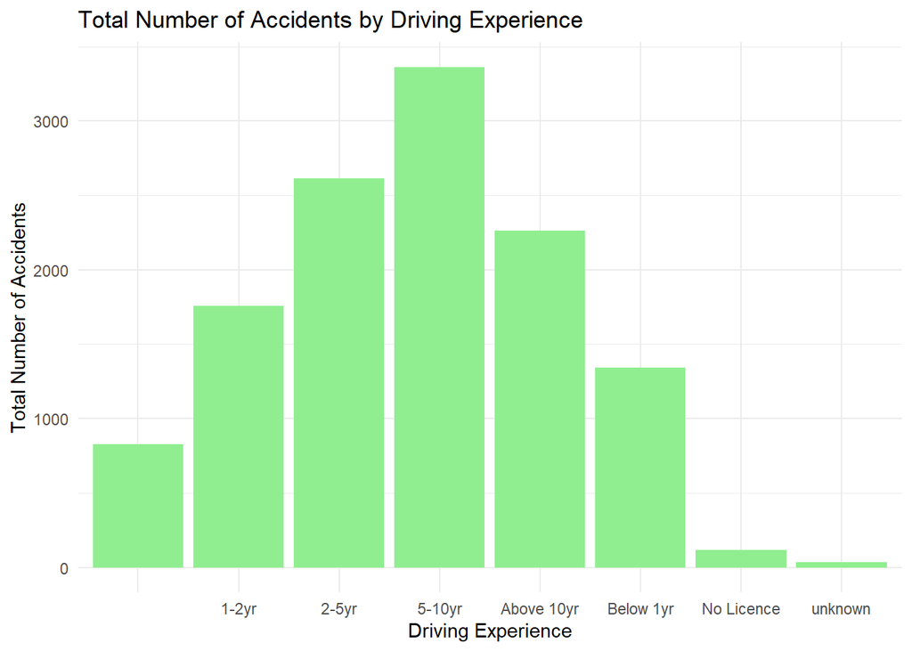

```r
ggplot(accidents_clean, aes(x = Driving_experience)) +
  geom_bar(fill = "lightgreen") +
  labs(title = "Total Number of Accidents by Driving Experience", x = "Driving Experience", y = "Total Number of Accidents") +
  theme_minimal()
```

```r
# Print total accidents by driving experience
table(accidents_clean$Driving_experience)
```

```
##
##                 1-2yr      2-5yr     5-10yr Above 10yr  Below 1yr No Licence
##        829       1756       2613       3363       2262       1342        118
##    unknown
##         33
```

## 5. What is the distribution of road accidents by the type of vehicle involved?

```r
# Load necessary libraries
library(ggplot2)
library(dplyr)

# Group by 'Type_of_vehicle' and count the number of accidents
vehicle_accidents <- accidents_clean %>%
  group_by(Type_of_vehicle) %>%
  summarise(accidents_count = n())

# View the result
print(vehicle_accidents)
```

```
## # A tibble: 18 × 2
##    Type_of_vehicle        accidents_count
##    <chr>                            <int>
##  1 ""                                 950
##  2 "Automobile"                      3205
##  3 "Bajaj"                             29
##  4 "Bicycle"                           21
##  5 "Long lorry"                       383
##  6 "Lorry (11?40Q)"                   541
##  7 "Lorry (41?100Q)"                 2186
##  8 "Motorcycle"                       177
##  9 "Other"                           1208
## 10 "Pick up upto 10Q"                 811
## 11 "Public (12 seats)"                711
## 12 "Public (13?45 seats)"             532
## 13 "Public (> 45 seats)"              404
## 14 "Ridden horse"                      76
## 15 "Special vehicle"                   84
## 16 "Stationwagen"                     687
## 17 "Taxi"                             265
## 18 "Turbo"                             46
```

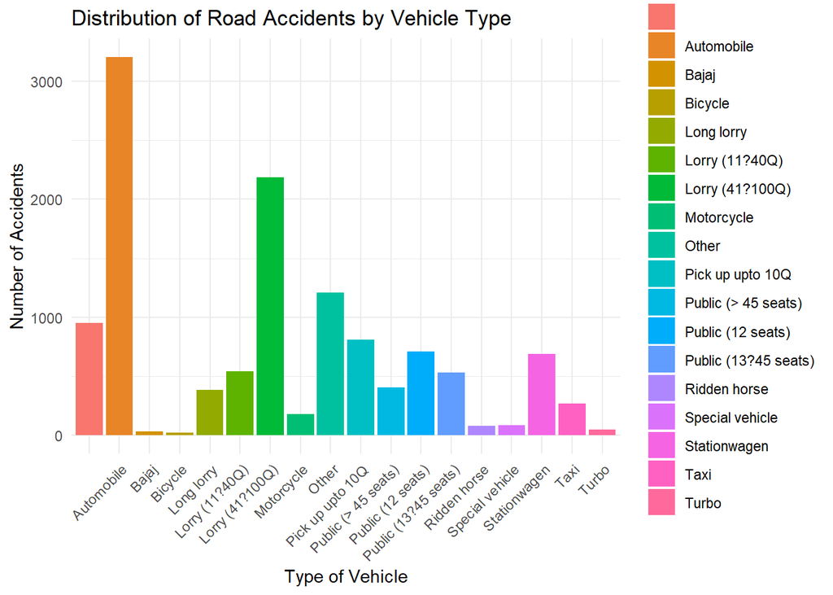

```r
# Create a bar plot to visualize the distribution
ggplot(vehicle_accidents, aes(x = Type_of_vehicle, y = accidents_count, fill = Type_of_vehicle)) +
  geom_bar(stat = "identity") +
  theme_minimal() +
  labs(title = "Distribution of Road Accidents by Vehicle Type",
       x = "Type of Vehicle", y = "Number of Accidents") +
  theme(axis.text.x = element_text(angle = 45, hjust = 1))
```

## Answer

Automobiles and Lorries (especially larger ones) dominate the number of accidents in Addis Ababa. Public transport vehicles also contribute notably to accident statistics. Motorcycles and smaller vehicles like Bajajs have a smaller presence but still contribute to the overall accident count.

## 6.Is there a correlation between road surface conditions and accident severity?

```r
# Create a contingency table for Road Surface Conditions vs Accident Severity
contingency_table <- table(accidents_clean$Road_surface_conditions, accidents_clean$Accident_severity)

# View the contingency table
print(contingency_table)
```

```
##
##                        Fatal injury Serious Injury Slight Injury
##   Dry                           121           1332          7887
##   Flood over 3cm. deep            0              0             2
##   Snow                            0              4            66
##   Wet or damp                    37            407          2460
```

```r
# Perform a Chi-squared test
chi_square_test <- chisq.test(contingency_table)
# Output the Chi-squared test result
print(chi_square_test)
```

```
##
##  Pearson's Chi-squared test
##
## data:  contingency_table
## X-squared = 5.7209, df = 6, p-value = 0.4552
```

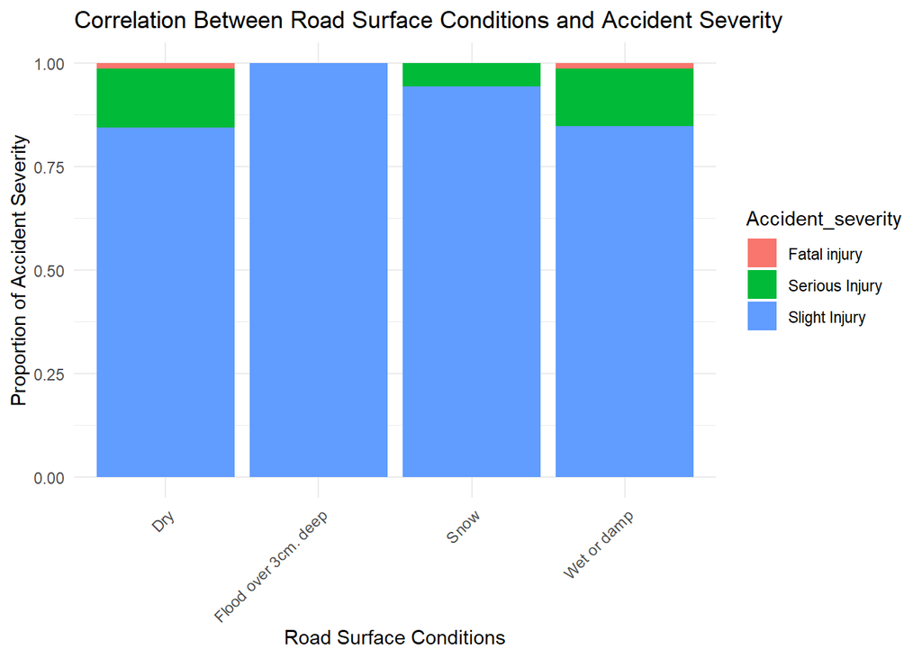

```r
# Visualization - Bar plot
ggplot(accidents_clean, aes(x = Road_surface_conditions, fill = Accident_severity)) +
  geom_bar(position = "fill") +
  theme_minimal() +
  labs(title = "Correlation Between Road Surface Conditions and Accident Severity",
       x = "Road Surface Conditions", y = "Proportion of Accident Severity") +
  theme(axis.text.x = element_text(angle = 45, hjust = 1))
```

## 7.Are there any noticeable trends in accident severity by road alignment type (e.g., curved, flat terrain)?

```r
# Create a contingency table for Road Alignment vs Accident Severity
contingency_table_alignment <- table(accidents_clean$Road_allignment, accidents_clean$Accident_severity)

# View the contingency table
print(contingency_table_alignment)
```

```
##
##                                                 Fatal injury Serious Injury
##                                                            2             22
##   Escarpments                                              1             14
##   Gentle horizontal curve                                  3             20
##   Sharp reverse curve                                      0              9
##   Steep grade downward with mountainous terrain            4             63
##   Steep grade upward with mountainous terrain              1              5
##   Tangent road with flat terrain                         140           1466
##   Tangent road with mild grade and flat terrain            2             77
##   Tangent road with mountainous terrain and                4             61
##   Tangent road with rolling terrain                        1              6
##
##                                                 Slight Injury
##                                                           118
##   Escarpments                                              98
##   Gentle horizontal curve                                 140
##   Sharp reverse curve                                      48
##   Steep grade downward with mountainous terrain           362
##   Steep grade upward with mountainous terrain              13
##   Tangent road with flat terrain                         8853
##   Tangent road with mild grade and flat terrain           422
##   Tangent road with mountainous terrain and               331
##   Tangent road with rolling terrain                        30
```

```r
# Perform a Chi-squared test
chi_square_test_alignment <- chisq.test(contingency_table_alignment)
# Output the Chi-squared test result
print(chi_square_test_alignment)
```

```
##
##  Pearson's Chi-squared test
##
## data:  contingency_table_alignment
## X-squared = 13.214, df = 18, p-value = 0.7787
```

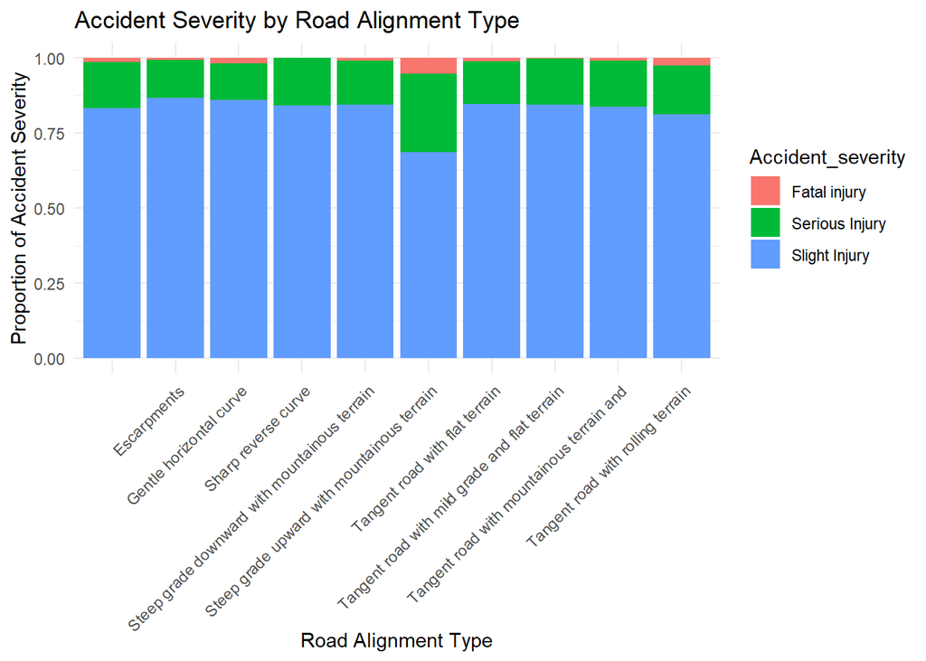

```r
# Visualization - Bar plot
ggplot(accidents_clean, aes(x = Road_allignment, fill = Accident_severity)) +
  geom_bar(position = "fill") +
  theme_minimal() +
  labs(title = "Accident Severity by Road Alignment Type",
       x = "Road Alignment Type", y = "Proportion of Accident Severity") +
  theme(axis.text.x = element_text(angle = 45, hjust = 1))
```

## Answer

As shown in the graph “Steep grade upward with mountainous terrain” have most of serious injuries in accidents. followed by “Tangent road wih rolling terrain” and “sharp reverse curve”.

## 8.What factors most predict severe accidents (e.g., weather, driving experience, road alignment)?

```r
# Convert Accident Severity into a binary outcome (Severe vs. Non-severe)
accidents_clean$Severity_binary <- ifelse(accidents_clean$Accident_severity %in% c("Serious Injury", "Fatal"), 1, 0)

# Build the logistic regression model
log_reg_model <- glm(Severity_binary ~ Weather_conditions + Driving_experience + Road_allignment +
                     Type_of_vehicle + Defect_of_vehicle + Area_accident_occured,
                     data = accidents_clean,
                     family = binomial)

# Summary of the model to interpret the coefficients
summary(log_reg_model)
```

```
##
## Call:
## glm(formula = Severity_binary ~ Weather_conditions + Driving_experience +
##     Road_allignment + Type_of_vehicle + Defect_of_vehicle + Area_accident_occured,
##     family = binomial, data = accidents_clean)
##
## Coefficients:
##                                                               Estimate
## (Intercept)                                                   -2.62931
## Weather_conditionsFog or mist                                  0.52124
## Weather_conditionsNormal                                       0.93229
## Weather_conditionsOther                                        0.44151
## Weather_conditionsRaining                                      0.68582
## Weather_conditionsRaining and Windy                           -0.23777
## Weather_conditionsSnow                                         0.29703
## Weather_conditionsUnknown                                      1.12785
## Weather_conditionsWindy                                        1.07151
## Driving_experience1-2yr                                       -0.18128
## Driving_experience2-5yr                                       -0.04304
## Driving_experience5-10yr                                      -0.11831
## Driving_experienceAbove 10yr                                  -0.06536
## Driving_experienceBelow 1yr                                    0.02434
## Driving_experienceNo Licence                                  -0.36587
## Driving_experienceunknown                                      0.19366
## Road_allignmentEscarpments                                    -0.44069
## Road_allignmentGentle horizontal curve                        -0.22938
## Road_allignmentSharp reverse curve                            -0.05056
## Road_allignmentSteep grade downward with mountainous terrain  -0.16144
## Road_allignmentSteep grade upward with mountainous terrain     0.79575
## Road_allignmentTangent road with flat terrain                 -0.24493
## Road_allignmentTangent road with mild grade and flat terrain  -0.10849
## Road_allignmentTangent road with mountainous terrain and      -0.12020
## Road_allignmentTangent road with rolling terrain              -0.17397
## Type_of_vehicleAutomobile                                      0.23796
## Type_of_vehicleBajaj                                          -0.29096
## Type_of_vehicleBicycle                                        -0.99597
## Type_of_vehicleLong lorry                                      0.44250
## Type_of_vehicleLorry (11?40Q)                                  0.49246
## Type_of_vehicleLorry (41?100Q)                                 0.06409
## Type_of_vehicleMotorcycle                                      0.35339
```

[output cut: 142 more lines]

```
## Area_accident_occuredResidential areas                        0.55916
## Area_accident_occuredRural village areas                      0.08562 .
## Area_accident_occuredRural village areasOffice areas          0.06502 .
## Area_accident_occuredSchool areas                             0.68109
## Area_accident_occuredUnknown                                  0.58323
## ---
## Signif. codes:  0 '***' 0.001 '**' 0.01 '*' 0.05 '.' 0.1 ' ' 1
##
## (Dispersion parameter for binomial family taken to be 1)
##
##     Null deviance: 10042.9  on 12315  degrees of freedom
## Residual deviance:  9935.6  on 12257  degrees of freedom
## AIC: 10054
##
## Number of Fisher Scoring iterations: 9
```

```r
# Model diagnostics - Check the significance of predictors
# Look at the coefficients, p-values, and odds ratios
exp(cbind(OR = coef(log_reg_model), confint(log_reg_model)))
```

```
##                                                                        OR
## (Intercept)                                                  7.212848e-02
## Weather_conditionsFog or mist                                1.684110e+00
## Weather_conditionsNormal                                     2.540318e+00
## Weather_conditionsOther                                      1.555059e+00
## Weather_conditionsRaining                                    1.985403e+00
## Weather_conditionsRaining and Windy                          7.883852e-01
## Weather_conditionsSnow                                       1.345860e+00
## Weather_conditionsUnknown                                    3.089023e+00
## Weather_conditionsWindy                                      2.919792e+00
## Driving_experience1-2yr                                      8.342046e-01
## Driving_experience2-5yr                                      9.578756e-01
## Driving_experience5-10yr                                     8.884220e-01
## Driving_experienceAbove 10yr                                 9.367265e-01
## Driving_experienceBelow 1yr                                  1.024640e+00
## Driving_experienceNo Licence                                 6.935927e-01
## Driving_experienceunknown                                    1.213688e+00
## Road_allignmentEscarpments                                   6.435939e-01
## Road_allignmentGentle horizontal curve                       7.950295e-01
## Road_allignmentSharp reverse curve                           9.507001e-01
## Road_allignmentSteep grade downward with mountainous terrain 8.509152e-01
## Road_allignmentSteep grade upward with mountainous terrain   2.216112e+00
## Road_allignmentTangent road with flat terrain                7.827621e-01
## Road_allignmentTangent road with mild grade and flat terrain 8.971899e-01
## Road_allignmentTangent road with mountainous terrain and     8.867467e-01
## Road_allignmentTangent road with rolling terrain             8.403197e-01
## Type_of_vehicleAutomobile                                    1.268661e+00
## Type_of_vehicleBajaj                                         7.475487e-01
## Type_of_vehicleBicycle                                       3.693647e-01
## Type_of_vehicleLong lorry                                    1.556590e+00
## Type_of_vehicleLorry (11?40Q)                                1.636343e+00
## Type_of_vehicleLorry (41?100Q)                               1.066189e+00
## Type_of_vehicleMotorcycle                                    1.423882e+00
## Type_of_vehicleOther                                         9.359840e-01
## Type_of_vehiclePick up upto 10Q                              1.416431e+00
## Type_of_vehiclePublic (> 45 seats)                           1.155945e+00
## Type_of_vehiclePublic (12 seats)                             1.133354e+00
## Type_of_vehiclePublic (13?45 seats)                          1.390470e+00
## Type_of_vehicleRidden horse                                  1.262296e+00
## Type_of_vehicleSpecial vehicle                               1.897306e+00
```

[output cut: 125 more lines]

```
## Defect_of_vehicleNo defect                                    1.2312843
## Area_accident_occured  Market areas                           1.6760426
## Area_accident_occured  Recreational areas                     1.3695592
## Area_accident_occured Church areas                            1.3683519
## Area_accident_occured Hospital areas                          1.2391524
## Area_accident_occured Industrial areas                        1.4658805
## Area_accident_occured Outside rural areas                     2.1232766
## Area_accident_occuredOffice areas                             1.4350101
## Area_accident_occuredOther                                    1.5082584
## Area_accident_occuredRecreational areas                              NA
## Area_accident_occuredResidential areas                        1.6839514
## Area_accident_occuredRural village areas                      1.0033470
## Area_accident_occuredRural village areasOffice areas          7.2125210
## Area_accident_occuredSchool areas                             1.4610278
## Area_accident_occuredUnknown                                  2.4103440
```

```r
# Model Evaluation: Calculate predictions and performance metrics
predictions <- predict(log_reg_model, type = "response")
predicted_classes <- ifelse(predictions > 0.5, 1, 0)

# Confusion matrix and accuracy
conf_matrix <- table(Predicted = predicted_classes, Actual = accidents_clean$Severity_binary)
accuracy <- sum(diag(conf_matrix)) / sum(conf_matrix)
print(paste("Accuracy: ", accuracy))
```

```
## [1] "Accuracy:  0.858557973367977"
```

## Answer

# Final Words

The study brings out the intensity that environmental factors, the experience of the driver, and the condition of the cars at the time of an accident plays. Preventing very high risk crashes may require policy measures that enhance driver training including first time drivers and vehicle safety inspection. Higher levels of investment in infrastructure could lead to reduction of accidents especially on areas characterized by steep gauges and mountainous regions.

This paper therefore highlights the significance of tailor made safety interventions and may aide in guiding the formulation of road safety polices and engineering designs. More precise data regarding weather conditions, car safety mechanisms, and effects of particular roads’ layout on the severity of an accident can be studied in future researches.

In conclusion it is argued that improvement of the above mentioned factors is crucial in the endeavor of promoting efforts and measures on road safety improvement as well as minimizing the occurrence of serious road accidents in Addis Ababa.